### Part1 Exponential Distribution vs. Central Limit Theorem

#### Overview

This project investigates the exponential distribution in R and compare it with the Central Limit Theorem. The exponential distribution is simulated with rexp(n, lambda) where lambda is the rate parameter, theoretical mean of exponential distribution is 1/lambda and theoretical standard deviation is also 1/lambda. This project performs a thousand simulations to get the distribution of averages of 40 exponentials, where the lambda is set to 0.2 for all of the simulations. The simulated samples are used to illustrate and explain the properties of the distribution of the mean of 40 exponentials in the following ways:

1. Show the sample mean and compare it to the theoretical mean of the distribution.
2. Show how variable the sample is (via variance) and compare it to the theoretical variance of the distribution.
3. Show that the distribution is approximately normal.

#### Simulations

Library required

```r
library(ggplot2)
lambda = 0.2 # Set lambda = 0.2 for all of the simulations
n = 40 # Investigate 40 exponentials...
nsims = 1:1000 # ...for 1000 simulations
set.seed(876) # setting seed for reproducing the data
means <- data.frame(x = sapply(nsims, function(x) {mean(rexp(n, lambda))})) # gathering means..
head(means)
```

```
##          x
## 1 4.129788
## 2 5.302187
## 3 4.699978
## 4 4.332842
## 5 5.726389
## 6 4.387737
```

Let’s graph it..

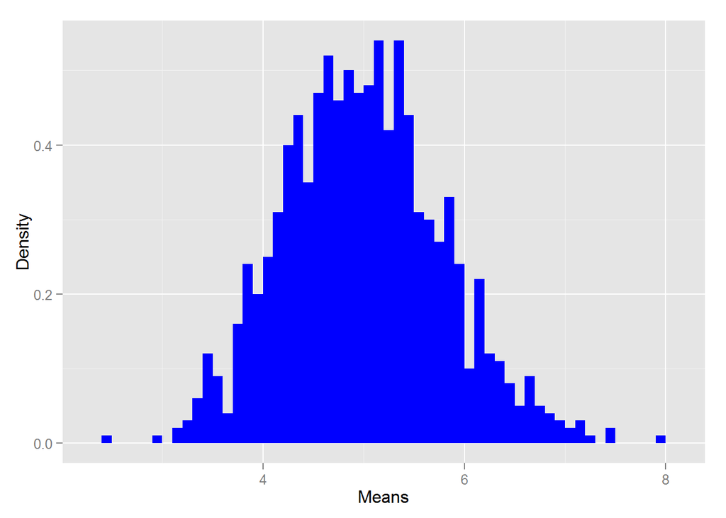

```r
ggplot(data = means, aes(x = x)) + geom_histogram(fill = "blue",binwidth=0.1, aes(y=..density..)) + labs(x="Means") + labs(y="Density")
```

#### Question 1: Sample Mean vs Theoretical Mean

Expected Mean of Exponential Distribution of lamda:

```r
simmu = 1 / lambda
print(simmu)
```

```
## [1] 5
```

Sample Mean of Exponential Distributions (nsims = 1:1000;n = 40) :

```r
simmean <- mean(means$x)
print(simmean)
```

```
## [1] 4.991893
```

#### Question 2: Sample Variance vs Theoretical Variance

Theoretical

```r
simexpsd <- (1/lambda)/sqrt(n) #standard deviation
print(simexpsd)
```

```
## [1] 0.7905694
```

```r
simexpvar <- simexpsd^2 #variance
print(simexpvar)
```

```
## [1] 0.625
```

Sample

```r
simsd <- sd(means$x) #standard deviation
print(simsd)
```

```
## [1] 0.78538
```

```r
simvar <- var(means$x) #variance
print(simvar)
```

```
## [1] 0.6168217
```

Results for Question 1 and for Question 2 are very close.

#### Question 3: Showing the distribution is approximately normal

From the graph, the distribution of the simulated means (blue) approaches the normal distribution (red) and that their means (blue and red vertical lines) approach each other too

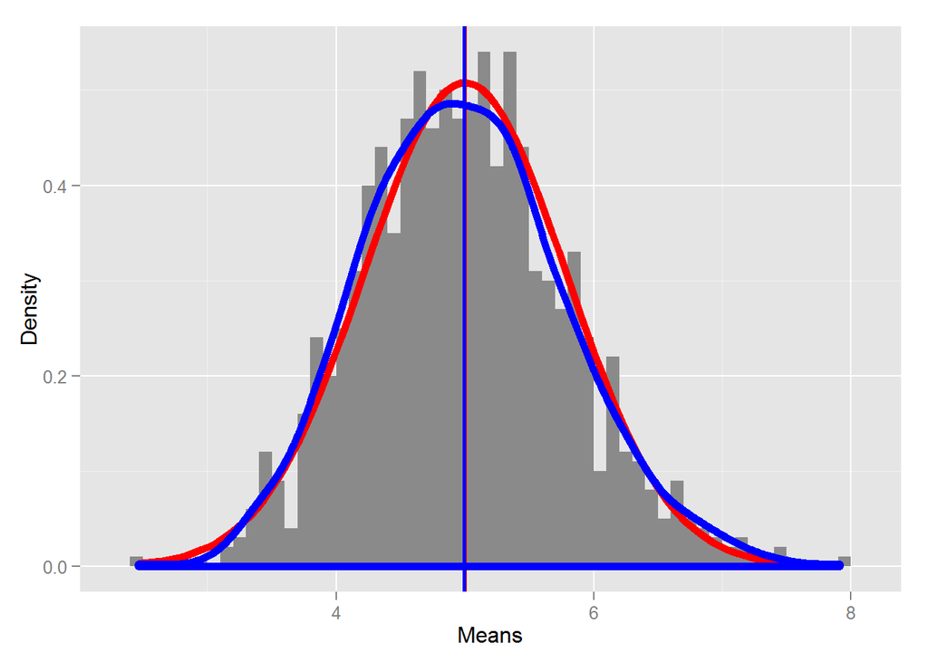

```r
ggplot(data = means, aes(x = x)) + geom_histogram(binwidth=0.1, aes(y=..density..), fill = I('#8A8A8A'),) + stat_function(fun = dnorm, arg = list(mean = simmu , sd = simsd), colour = "red", size=2) + geom_vline(xintercept = simmu, size=1, colour="red") + geom_density(colour="blue", size=2) + geom_vline(xintercept = simmean, size=1, colour="blue") + labs(x="Means") +labs(y="Density")
```